# Course 8 Final Project

Snehangshu Roy

05/01/2022

## Introduction

The above sections are intentionally presented in a way that reflects the data science pipeline suggested by the Cross-industry Standard Process for Data Mining (CRISP_DM) (Shearer 2000).

## Data Preparation

We load the data set from the source given. The train data is the main csv file and the validation data is the pml-testing.csv. To make model of the data diven we grab only the numeric columns. As some data have bigger absolute value so we take scale of the data to standardize it.

```r
# Loading the dataset
trainData_original = read.csv("pml-training.csv")
validData_original = read.csv("pml-testing.csv")

# loading the libraries
# Libraries
library(dplyr)
library(caret)
library(gbm)
library(randomForest)
library(rpart)
library(rattle)
# only grabbng the numeric columns

numcoltrain = sapply(trainData_original, is.numeric)
numcoltest = sapply(validData_original, is.numeric)

traindata = trainData_original[, numcoltrain ]
validData = validData_original[,numcoltest]



#we need to predict on the the test data
# so only takes the columns from trainselt which are in common with test set
colset = colnames(validData)


traindata = traindata %>% select(colset[-57])

# scale training data
traindata = scale(traindata)
traindata = as.data.frame(traindata)
#adding the predictor variable
traindata$classe = trainData_original$classe

traindata$classe = factor(traindata$classe)
```

## Model Building & Exploratory Data Analysis

After the data preparation model building will be carried out. We have considered the model of Decision Tree and Random Forest. The initial train data will be devided to train and test the models. To improve the caret package speed the cross-validation technique will be used.

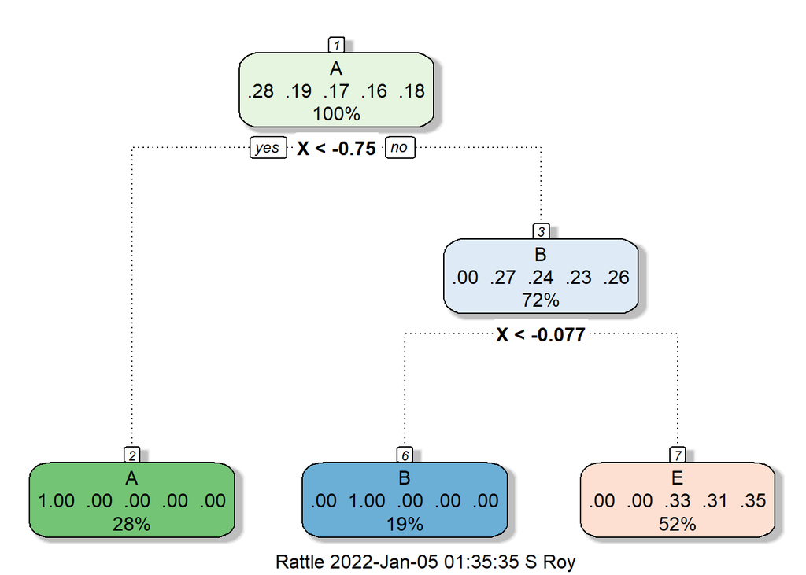

```r
set.seed(123)
intrain = createDataPartition(y=traindata$classe, p=.6, list = F )

traindata = traindata[intrain,]
testdata = traindata[-intrain,]

fitControl = trainControl(method='cv', number = 3)

#testing Decision Tree Model

modelDT = train(classe~., traindata, method = "rpart", trControl=fitControl)
# piloting the Decision Tree Model
fancyRpartPlot(modelDT$finalModel)
```

In next step the accurary of the model will be tested.

```r
pred_classDT = predict(modelDT, testdata)


confusionMatrix(pred_classDT, testdata$classe)$overall[1]
```

```
##  Accuracy
## 0.6602333
```

It was found that the model accuracy is only 66 %. It can be improved using the RandomForest Method.

```r
# testing Random Forest model

modelRF = train(classe ~ ., data= traindata, method = "rf", ntree=100,
                trControl = fitControl)

pred_classRF = predict(modelRF, testdata)


confusionMatrix(pred_classRF, testdata$classe)$overall[1]
```

```
## Accuracy
##        1
```

The new model able to able to check with higher accuracy. Checking the model with some plots

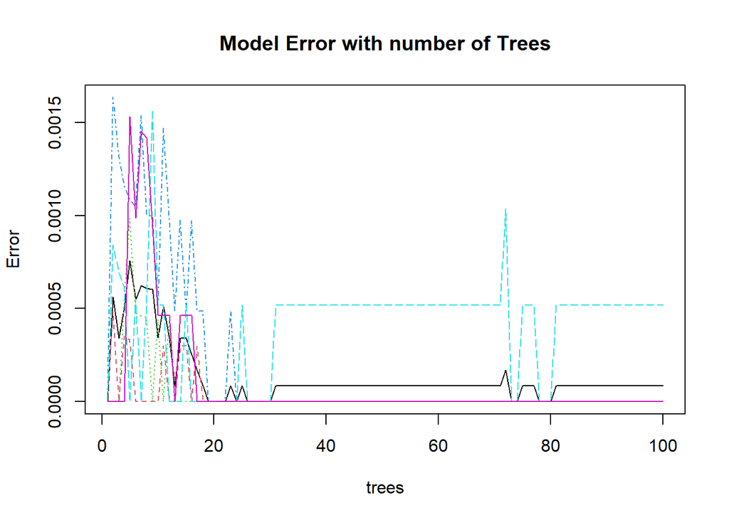

```r
plot(modelRF$finalModel, main = "Model Error with number of Trees")
```

Checking effect of the predictos

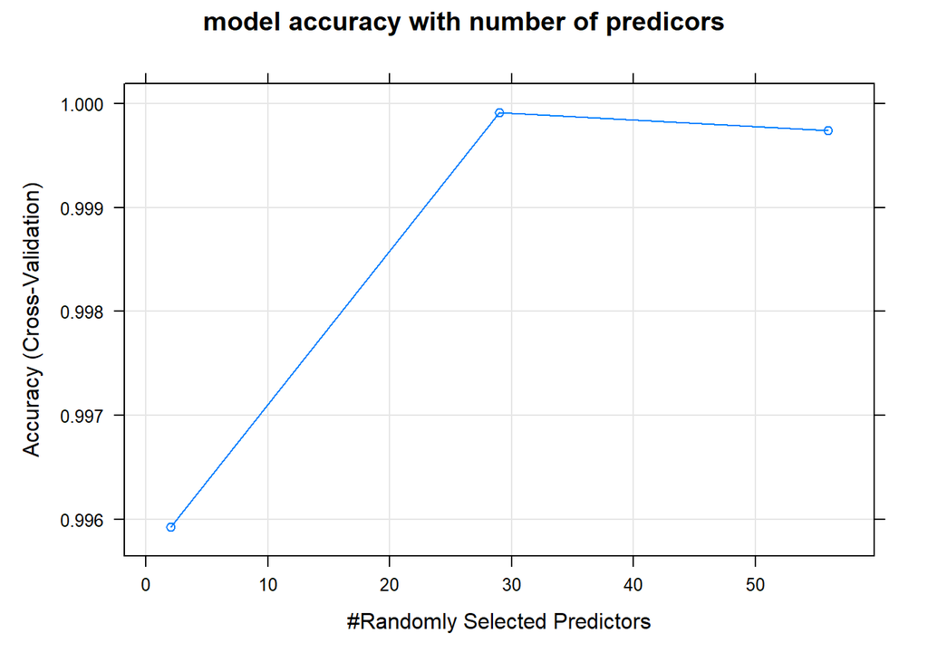

```r
plot(modelRF, main = "model accuracy with number of predicors")
```

Checking the model with the validation dat

```r
newdata = scale(validData)
newdata= as.data.frame(newdata)

pred_validation = predict(modelRF, newdata = newdata[-57])
pred_validation
```

```
##  [1] A A A A A A B B B E C C C D D D E E E E
## Levels: A B C D E
```